# Computer Science 1

**Computer lab 04**

**Course Number:** BTPS1210BA-E  
**Contact Information:** Please contact me through email anytime: abari.kalman@arts.unideb.hu

Author

Kálmán Abari

Published

August 28, 2024

Learning outcomes

Students will learn how to use datasets.

# TXT, CSV, Spreadsheets

## Problem 1

> In this section, you will learn how to create a simple dataset by hand.

Five kindergarteners participated in a *Treasure hunt* program, where the goal is to choose the sport that best suits them. Peter’s height is 134 cm and he lives 12.9 km from the Sports Center. Jennifer is 132 cm and lives 3.4 km away, Zoe is 141 cm and lives 21.3 km away, Mary is 138 cm tall and lives 12.1 km away, and Christian is 144 cm tall and lives 65.6 km away. All children were assessed with the Aptitude test and received the following values, respectively: 34, 12, 56, 47, 29. Aptitude tests help psychologists understand the learning ability of a child. Create a dataset that includes the above information. Create XLSX, CSV, TXT and OMV versions of the dataset.

1. Create a new Excel document `treasure_hunt.xlsx` in a new project directory `kindergarteners`.
2. Enter the data according to the rules you have learned, then save the file. The contents of the Excel file are as shown below. **(Be careful with the decimal point, as the image below was created in Hungarian Excel, so a comma was used to indicate the decimal point. In English Excel it is customary to use a period when typing the decimal point.)**

[figure not shown]

   treasure_hunt.xlsx

3. In Excel, save the file `treasure_hunt.xlsx` in *CSV (comma separated)* file format. It creates the file `treasure_hunt.csv`. Open this file in the Notepad application.

[figure not shown]

   As you can see this file above is separated by a tab, the decimal point is a comma because of the Hungarian context. In English, the decimal point is the period. The file looks messy to the human eye, but let’s be clear, it is not intended for human reading, but for machine reading.
4. In Excel, save the file `treasure_hunt.xlsx` in *TXT (text, TAB separated)* format. It creates the file `treasure_hunt.txt`. Open this file in the Notepad application.

[figure not shown]

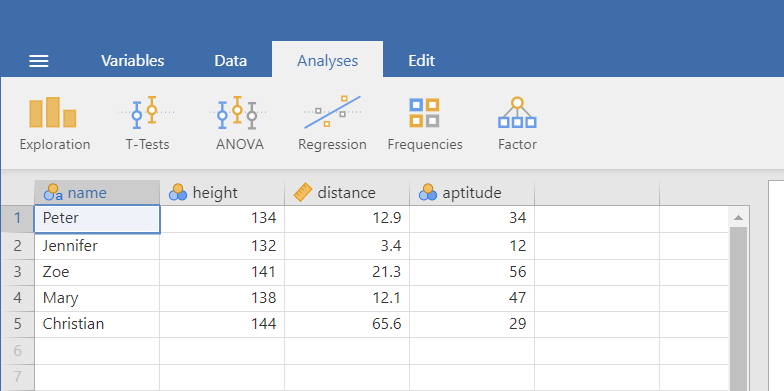

   treasure_hunt.omv

6. Create a compressed zip file (`treasure_hunt.zip`) from the XLSX, CSV, TXT and OMV versions of the dataset.
7. Send the file `treasure_hunt.zip` to the `abari.kalman@arts.unideb.hu`. The subject of this email is `Problem 1`.

## Problem 2

> In this section, you will learn how to create a tidy dataset.

The tidy data format has a rectangular shape which means it has columns, rows, and cells, just like in a spreadsheet. However, for rectangular data to be tidy, there are three major principles to adhere to:

- Each column should hold a single variable
- Each row should hold a single observation.
- Each cell should hold a single value (if you follow the first two rules, then each cell should have a single value)
1. Download the untidy.xlsx and make its tidy equivalent. The dataset uses hypothetical data for four children.

[figure not shown]

   Untidy dataset

The dataset is untidy because

- multiple variables are stored in one column: The column `sex and age` has two variables, obviously `sex` and `age`. For example Mike’s value for this column is `m_12`, meaning that he is a 12 year old male. The sex and age values need to be in different columns.
- the units are mixed and listed with the observations: For height and weight, we only need the values converted to the same units.
- variable names are usually in lower case and do not contain spaces, if you want to break them up, use underscores.
2. Verify that the new database looks as shown in the image. Save the tidy dataset as `tidy.xlsx`.

[figure not shown]

   Tidy dataset

3. Send the file `tidy.xlsx` to the `abari.kalman@arts.unideb.hu`. The subject of this email is `Problem 2`.

## Problem 3

> In this section, you will learn how to join datasets.
1. Download survey_01.xlsx and survey_02.xlsx.
2. As you can see, the two files contain the imaginary data of 5 children.

[figure not shown]

[figure not shown]

   The dataset `survey_01.xlsx` contains demographic results, while `survey_02.xlsx` contains test results. The common link is the child ID (`id` column). Merge the data in the two dataset into a single dataset. Be careful, because 1-1 child is missing from both data tables.
3. Verify that the new dataset looks as shown in the image. Save the merged dataset as `survey.xlsx`.

[figure not shown]

   survey.xlsx

4. Send the file `survey.xlsx` to the `abari.kalman@arts.unideb.hu`. The subject of this email is `Problem 3`.